# NHP Glucose, Body Weight, and Body Comp

Eric Shiroma, John Nam

2020 April 07

## Study Description

- This is an investigation into the longitudinal trajectories of glucose, body weight, and body composition in NHP (non-human primate colonies). These results will be used to compare similar trajectories in mice and humans.

## Analysis

#### function to coalesce columns with missing values

#### data read in (nia colony)

- input files from NHP_NIA_raw folder
  - Copy of #2 - CR Study_FBG Data.xlsx (1/2/2019)
  - Copy of #4 - Other Rhesus_FBG Data.xlsx (4/9/2019)
  - Copy of NHP-NIA_average FBG_042319.xlsx (4/23/2019)
  - Copy of NHP-NIA_LT CR dexa data_Michel.xlsx (10/15/2019)
  - NIA_mortality_list2_update032020_v2.xlsx (3/20/20)

#### glucose cleaning (nia colony)

- CR study (CR_FBG2)
- other rhesus (other_FBG2)

#### body composition cleaning (nia colony)

- CR study (CR_dexa4)
  - calculate body weight from fat and % fat
  - normalize units to kg

#### survival census cleaning (nia colony)

#### merging datasets for census creation (nia colony)

- other_FBG2
- CR_dexa2
- surv_nia

#### data read in (wisconsin colony)

- input files from NHP_WIS_raw folder
  - Copy of Control Glucose_.xlsx (4/28/2019)
  - Copy of WIS-NHP DXA data_Michel.xlsx (4/29/2019)
  - Euth.Nat.xlsx (1/17/2020)
  - GlucoseDate.DOBDOD.xlsx (12/2/2019)

#### glucose creation (wisconsin colony)

- using provided age since dates are not provided in glucose file
- pulled in sex from IVGTT as some are missing from glucose file
- converted age to months
- converted measures into kg

#### survival census creation (wisconsin colony)

#### merging datasets for census creation (wisconsin colony)

- DEXA2
- surv_wis

#### merging datasets for glucose creation (all colonies)

- other_FBG2 (nia)
- FBG2 (wis)

#### merging datasets for body composition creation (all colonies)

- CR_dexa4 (nia)
- DEXA2 (wis)

#### merging datasets for census creation (all colonies)

- census_nia (nia)
- census_wis (wis)
- set all monkeys missing diabetes information as “Non-Diabetic”

#### merging datasets for census creation (all colonies)

- surv_nia (nia)
- surv_wis (wis)

#### merging datasets into a main file (all colonies)

- glucose
- bodycomp
- census

#### study bounded to non-caloric restriction diet monkeys

- total monkeys: 354
  - monkeys on caloric restriction diet: 91
  - monkeys on control diet: 263

#### restriction of monkeys with young deaths before 10 years of age

- “464”, “9G3”, “9GI”, “CH159”, “47Z”
  - monkeys after young death censor: 259
    - one already removed for diet

#### restriction of monkeys removed from study for health reasons

- “87L” (recycled 12/96), “CH48” (removed for cachexia 1/90)
  - monkeys after health censor: 258
    - one already removed for diet

#### excluding monkeys with no valid metabolic index values

- “833”, “O3”, “O89”, “OO5”
  - monkeys after valid value censor: 254

#### population characteristics

- 254 monkeys with valid indices
- 43.70 % female
- 14.96 % wis
- 3.54 % diabetic

#### age characteristics

Age Characteristics

| group1 | n | mean | sd | median | trimmed | mad | min | max | range | skew | kurtosis | se |
| --- | --- | --- | --- | --- | --- | --- | --- | --- | --- | --- | --- | --- |
| all | 254 | 126.73 | 74.56 | 114.57 | 120.58 | 74.98 | 9.00 | 472.00 | 463.00 | 0.92 | 1.25 | 4.68 |
| F | 111 | 120.33 | 66.55 | 114.15 | 116.15 | 72.43 | 9.00 | 307.00 | 298.00 | 0.49 | -0.39 | 6.32 |
| M | 143 | 131.70 | 80.10 | 115.00 | 123.81 | 81.54 | 21.00 | 472.00 | 451.00 | 1.05 | 1.47 | 6.70 |
| nia | 216 | 126.22 | 80.13 | 103.00 | 119.28 | 80.80 | 9.00 | 472.00 | 463.00 | 0.89 | 0.77 | 5.45 |
| wis | 38 | 129.67 | 26.26 | 123.55 | 129.88 | 21.25 | 78.38 | 174.84 | 96.46 | 0.20 | -0.89 | 4.26 |

#### frequencies of measures

Assessment Frequencies

| indicies | n | mean | sd | median | trimmed | mad | min | max | range | skew | kurtosis | se |
| --- | --- | --- | --- | --- | --- | --- | --- | --- | --- | --- | --- | --- |
| glucose | 254.00 | 18.61 | 21.08 | 7.00 | 14.91 | 7.41 | 0.00 | 79.00 | 79.00 | 1.30 | 0.47 | 1.32 |
| body weight | 254.00 | 7.18 | 11.16 | 0.00 | 4.89 | 0.00 | 0.00 | 41.00 | 41.00 | 1.43 | 0.94 | 0.70 |
| fat | 254.00 | 7.18 | 11.16 | 0.00 | 4.89 | 0.00 | 0.00 | 41.00 | 41.00 | 1.43 | 0.94 | 0.70 |

#### census_c16_death creation

- merge
  - census
  - surv
  - main_all2
  - restrict to non-caloric restriction diet monkeys (from original census and survival file)
  - restrict to monkeys that lived past 10 years (from original census and survival file)
    - “464”, “9G3”, “9GI”, “CH159”, “47Z”
  - excluding monkeys with no valid metabolic index values
    - “833”, “O3”, “O89”, “OO5”
  - create all cause death censor category

#### death frequency

Death Frequency

| Dead = 1 | Frequency |
| --- | --- |
| 0 | 167 |
| 1 | 87 |

#### follow up time

Follow Up Time

| vars | n | mean | sd | median | trimmed | mad | min | max | range | skew | kurtosis | se |
| --- | --- | --- | --- | --- | --- | --- | --- | --- | --- | --- | --- | --- |
| 1.00 | 254.00 | 106.17 | 103.81 | 66.00 | 91.48 | 62.27 | 0.00 | 389.40 | 389.40 | 1.06 | -0.11 | 6.51 |

#### life expectancy

Life Expectancy

|  | Sex | Total | Dead | Life Expectancy (months) | sd |
| --- | --- | --- | --- | --- | --- |
| 1 | all | 254 | 87 | 322.40 | 77.21 |
| 2 | female | 111 | 37 | 293.26 | 82.47 |
| 3 | male | 143 | 50 | 343.97 | 65.95 |
| 4 | nia | 216 | 50 | 336.85 | 85.87 |
| 5 | wis | 38 | 37 | 302.87 | 59.34 |

#### age at peak index value creation

#### main_cat2 creation

- merge
  - main_all2
  - census_c16_death
- create categories by survival length
  - needed for survival bias sensitivity

#### main_all3 creation

- merge
  - main_all2
  - census_c16_death
  - main_cat2

## Results

#### distribution figure with trend line

- generalized additive model for main indices
- linear model with quadratic fit for lifespan groups (survival bias analyses)

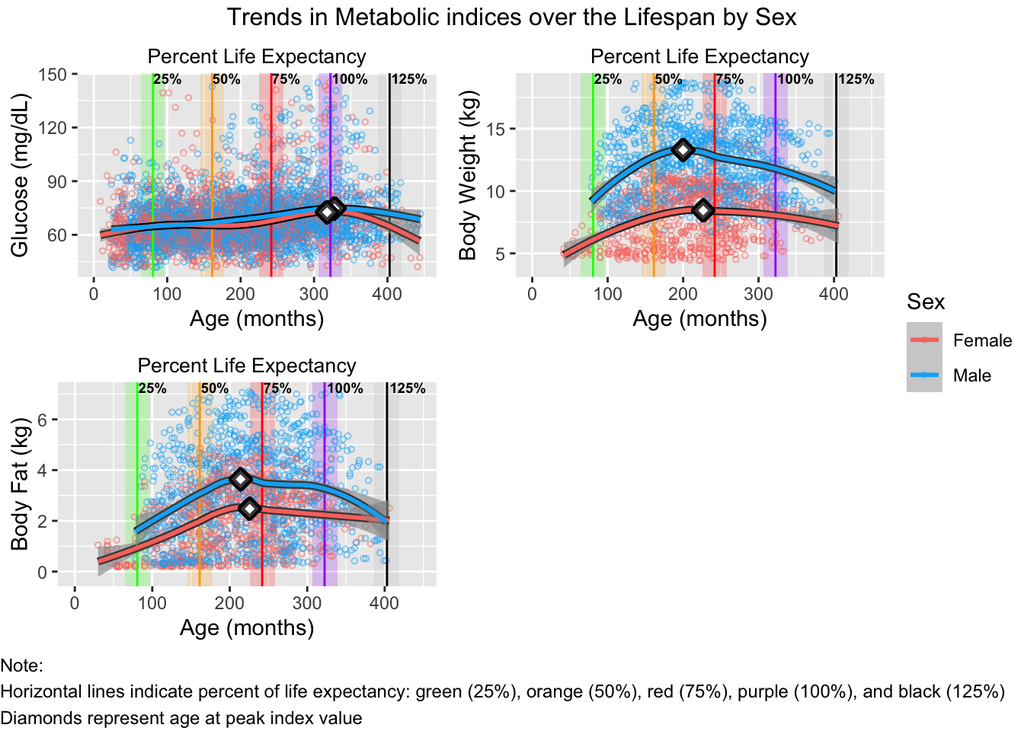

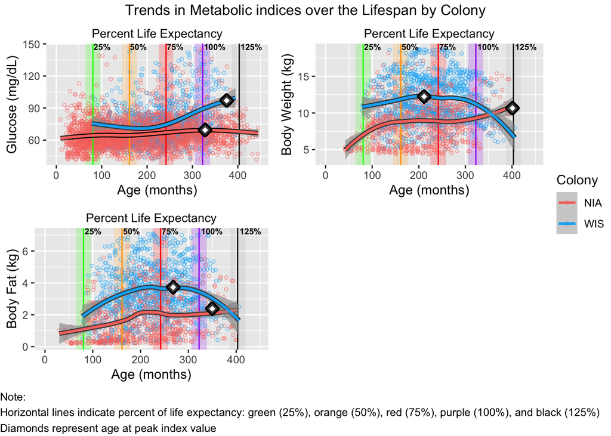

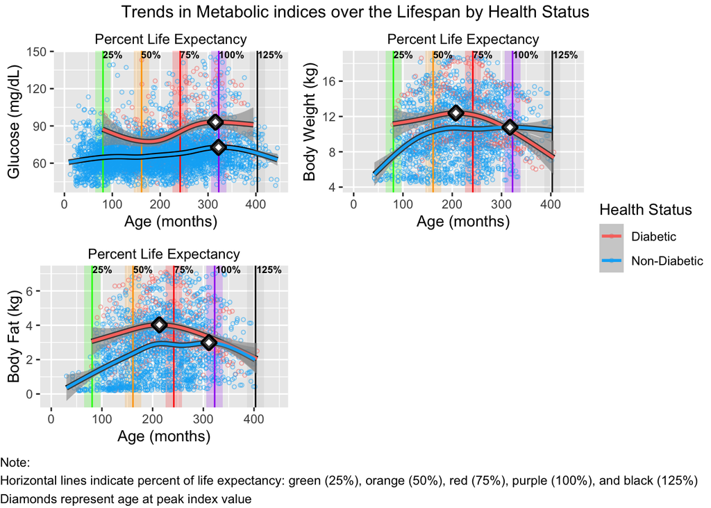

#### pre and post-peak change creation

#### change in metabolic indices pre and post-peak

- rate of percent change

Rate of Percent Change for Metabolic indices Pre- and Post-peak

| Metabolic Index | Age at Peak Value$^‡$ (% life expectancy) All | Age at Peak Value$^‡$ (% life expectancy) Female | Age at Peak Value$^‡$ (% life expectancy) Male | Pre-Peak$^§$$^¶$ All | Pre-Peak$^§$$^¶$ Female | Pre-Peak$^§$$^¶$ Male | Post-Peak$^§$$^¶$ All | Post-Peak$^§$$^¶$ Female | Post-Peak$^§$$^¶$ Male |
| --- | --- | --- | --- | --- | --- | --- | --- | --- | --- |
| gluc | 100.08 (90.26, 116.32) | 108.39 (94.11, 124.8) | 95.36 (82.86, 124.14) | 0.99 ( 0.90, 1.07)* | 0.76 ( 0.64, 0.88)* | 1.09 ( 0.97, 1.21)* | -1.31 (-1.80, -0.82)† | -0.87 (-1.81, 0.07)† | -1.16 (-1.89, -0.44)† |
| bw | 63.29 (50.25, 124.69) | 77.28 (59.33, 124.05) | 58.14 (47.1, 75.01) | 5.26 ( 4.32, 6.21)† | 3.84 ( 3.08, 4.60)† | 5.04 ( 3.80, 6.29)† | -1.09 (-1.98, -0.20)† | -0.89 (-1.71, -0.07)† | -2.10 (-2.89, -1.32)† |
| fat | 66.42 (57.69, 124.69) | 76.97 (63.42, 124.05) | 62.21 (50.59, 114.54) | 16.69 (14.31, 19.08)† | 17.74 (15.02, 20.46)† | 13.15 ( 9.09, 17.22)† | -3.36 (-5.15, -1.57)† | -1.52 (-3.17, 0.14)† | -4.52 (-6.59, -2.45)† |

* p value < 0.05  
† Insufficient sample size to conduct a statistical test of significance  
‡ Mean (range of ages at similar values) of age at peak index value  
<sup>§</sup> Mean (95% confidence interval) rate of percent change during phase per five percent change in life expectancy  
<sup>¶</sup> Pre-peak is defined as 25% life expectancy to age at peak value; post-peak phase is defined as peak to 125% life expectancy  
** Male and female estimates are based on sex specific life expectancy

#### kaplan meier survival curves

- comparing highest to lowest quartile
- three timepoints: 50, 75, and 100% life expectancy

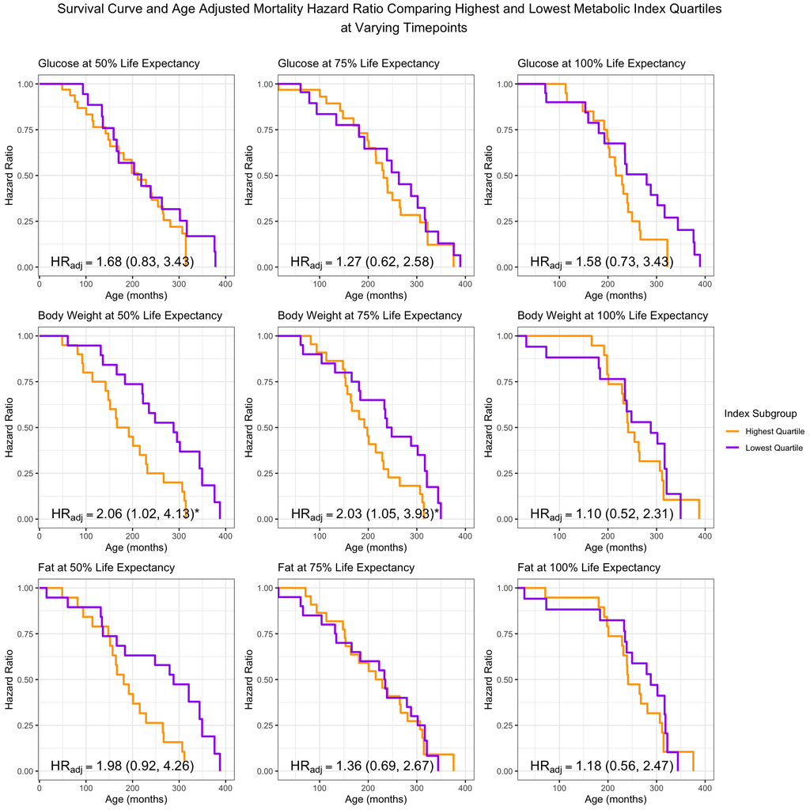

#### cox proportional mortality hazard ratios

- sex specific
- covariate adjustment
  - sex, age
  - additional adjustment for body fat

Mortality Hazard Ratios of Highest and Lowest Glucose Quartiles at Varying Timepoints Stratified by Sex

| Timepoint | All Model 1 | All Model 2 | Female Model 1 | Female Model 2 | Male Model 1 | Male Model 2 |
| --- | --- | --- | --- | --- | --- | --- |
| 50 | 1.60 (0.77, 3.30) | 0.87 (0.36, 2.09) | 0.76 (0.24, 2.46) | 0.46 (0.13, 1.72) | 6.62 (2.21, 19.81)* | 2.67 (0.72, 9.90) |
| 75 | 1.25 (0.61, 2.56) | 1.16 (0.51, 2.64) | 0.38 (0.11, 1.34) | 0.17 (0.03, 0.87)* | 2.94 (1.17, 7.34)* | 2.94 (1.04, 8.31)* |
| 100 | 1.65 (0.75, 3.63) | 0.55 (0.17, 1.78) | 0.26 (0.06, 1.03) | 0.41 (0.02, 9.28) | 3.95 (1.47, 10.59)* | 0.65 (0.12, 3.36) |

* p-value < 0.05  
† Hazard ratios (95% confidence intervals) are adjusted for: Model 1) age and sex; Model 2) additionally adjusted for body composition

Mortality Hazard Ratios of Highest and Lowest Body Weight and Composition Quartiles at Varying Timepoints Stratified by Sex

| Metabolic Index | Timepoint$^†$ | All | Female | Male |
| --- | --- | --- | --- | --- |
| Body Weight | 50 | 2.07 (1.03, 4.17)* | 2.58 (0.86, 7.79) | 1.80 (0.71, 4.56) |
|  | 75 | 2.02 (1.04, 3.93)* | 2.52 (0.83, 7.69) | 1.41 (0.59, 3.35) |
|  | 100 | 1.10 (0.52, 2.31) | 1.16 (0.32, 4.25) | 0.93 (0.37, 2.34) |
| Body Composition | 50 | 1.99 (0.92, 4.27) | 2.39 (0.71, 8.10) | 1.58 (0.56, 4.49) |
|  | 75 | 1.36 (0.69, 2.67) | 1.93 (0.57, 6.56) | 1.03 (0.45, 2.36) |
|  | 100 | 1.18 (0.56, 2.48) | 1.21 (0.27, 5.34) | 1.19 (0.48, 2.94) |

* p-value < 0.05  
† Hazard ratios are adjusted for age and sex  
‡ Timepoint is percent of mean life expectancy

## Author Questions

#### determine assessments over lifespan

Assessments of Metabolic indices Over the Lifespan

| Timepoint$^‡$ | Population New Participants | Population Alive | Population Dead | Glucose Measured | Glucose Imputed | Glucose Missing | Body Weight Measured | Body Weight Imputed | Body Weight Missing | Body Composition Measured | Body Composition Imputed | Body Composition Missing |
| --- | --- | --- | --- | --- | --- | --- | --- | --- | --- | --- | --- | --- |
| 25 | 112 | 137 | 48 | 130 | 0 | 7 | 52 | 0 | 85 | 52 | 0 | 85 |
| 50 | 77 | 166 | 54 | 162 | 1 | 3 | 79 | 2 | 85 | 79 | 2 | 85 |
| 75 | 32 | 144 | 64 | 143 | 0 | 1 | 84 | 2 | 58 | 84 | 2 | 58 |
| 100 | 7 | 87 | 60 | 84 | 1 | 2 | 46 | 27 | 14 | 46 | 27 | 14 |
| 125 | 1 | 28 | 28 | 28 | 0 | 0 | 9 | 16 | 3 | 9 | 16 | 3 |

* Imputation using last observed value carried forward  
† Timepoint is percent of mean life expectancy

#### trajectories by varying survival groups

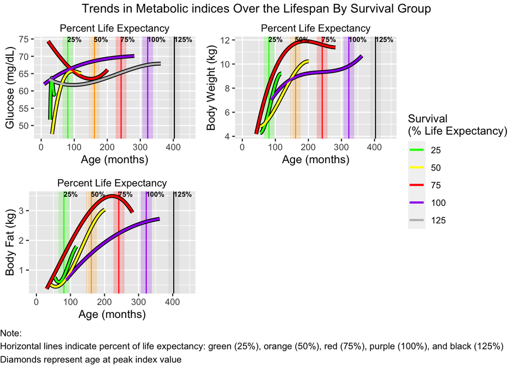